# Data Science: Assignment 04

Author

Madeleine Adelson

## The data set

The following visualizations are created using [New York City’s Property Valuation and Assessment Data set](https://data.cityofnewyork.us/City-Government/Property-Valuation-and-Assessment-Data/yjxr-fw8i/about_data). Housing affordability is one of my primary policy interests, and the valuation of property has an impact on both on mortgages paid by homeowners as well as rents paid to landlords. I wanted to investigate trends in housing valuations in New York City as a way of better understanding how values vary across the city, across different housing types, and over time.

As a first step, I imported my data. I then filtered it: the original data file is extremely large and includes records for all types of properties, not just residential ones. I removed non-residential properties, vacant lots, and properties owned by the New York Housing Authority or the City of New York - while these represent important housing stock, they may not follow market price/value trends in the same way as privately-owned property. I selected only the columns I was interested in, kept only the most recent 5 years, and removed some rows with missing data.

I also created three columns:

- Converted the original column YEAR to a standard year (original format is “2018/19”; I kept the first year in the range for each)
- Names of the boroughs instead of just number codes (1-5)
- Types of residences based on the BLDGCL (building)

```r
library(tidyverse)
library(scales)
library(sf)
library(tigris)

res_data <- read_csv("/Users/madeleineadelson/IDrive Downloads/MadeleinesMacBookAir/Users/madels01/Documents/Coursework/Georgetown/2024 Fall/Data Science/assignment04/data/Property_Valuation_and_Assessment_Data.csv", lazy = TRUE) |>
  filter(TAXCLASS %in% c("1","1A","1B","1C","1D","2","2A","2B","2C"),
         YEAR %in% c("2014/15", "2015/16", "2016/17", "2017/18", "2018/19"),
         FULLVAL > 0,
         OWNER != "NA",
         OWNER != "NEW YORK CITY HOUSING",
         OWNER != "NYC HOUSING AUTHORITY",
         OWNER != "NYC HOSUING AUTHORITY",
         OWNER != "CITY OF NEW YORK",
         BLDGCL != "G0",
         BLDGCL != "V0",
         BLDGCL != "V3",
         BLDGCL != "Z0"
         ) |>
  select(BBLE, BORO, BLOCK, LOT, OWNER, BLDGCL, TAXCLASS, STORIES, FULLVAL, AVTOT, STADDR, POSTCODE, YEAR, Longitude, Latitude) |>
  mutate(yearcln = case_when(
    YEAR == "2014/15" ~ 2014,
    YEAR == "2015/16" ~ 2015,
    YEAR == "2016/17" ~ 2016,
    YEAR == "2017/18" ~ 2017,
    YEAR == "2018/19" ~ 2018),
    boro_name = case_when(
    BORO == 1 ~ "Manhattan",
    BORO == 2 ~ "Bronx",
    BORO == 3 ~ "Brooklyn",
    BORO == 4 ~ "Queens",
    BORO == 5 ~ "Staten Island"),
    bldg_cat = case_when(
    BLDGCL %in% c("A0","A1","A2","A3","A4","A5","A6","A7","A9") ~ "Single Family",
    BLDGCL %in% c("B1","B2","B3","B9") ~ "Two Family",
    BLDGCL %in% c("C0","C1","C2","C3","C4","C5","C6","C8","C9","R2") ~ "Walk-Up Apartments/Condos",
    BLDGCL %in% c("C7","D6","D7","S0","S1","S2","S3","S4","S5","S9") ~ "Mixed Use",
    BLDGCL %in% c("D0","D1","D2","D3","D4","D5","D8","D9","R4") ~ "Elevator Apartments/Condos",
    TRUE ~ NA
    )
  )
```

## First visualization: How have property values changed over time in each borough?

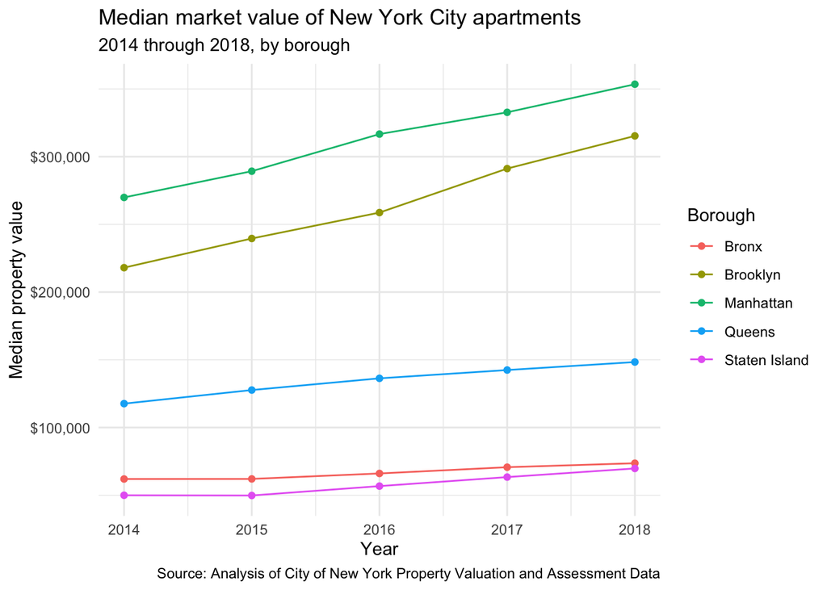

```r
res_data |>
  filter(TAXCLASS %in% c("2", "2A", "2B", "2C")) |>
  group_by(yearcln, boro_name) |>
  summarize(
    medval = median(FULLVAL)
  ) |>
  ggplot() +
  geom_line(mapping = aes(x = yearcln, y = medval, color = boro_name)) +
  geom_point(mapping = aes(x = yearcln, y = medval, color = boro_name)) +
  labs(title = "Median market value of New York City apartments",
       subtitle = "2014 through 2018, by borough",
       color = "Borough",
       caption = "Source: Analysis of City of New York Property Valuation and Assessment Data") +
  xlab("Year") +
  ylab("Median property value") +
  scale_y_continuous(labels = label_dollar()) +
  theme_minimal()
```

The chart above gives a sense of the relative market value of apartments in each borough and how those values changed from 2014-2018. I restricted this analysis to buildings classed as apartment buildings (4+ units); there seem to be some issues with comparing property values across different property types such as single-family homes.

Median market values have increased in all boroughs. Values are highest - and rising fastest, in terms of dollars - in Manhattan and Brooklyn. The large gap in values between these two boroughs and the others should inform choices made about how to allocate housing assistance, in conjunction with other data on the need for assistance and resident incomes across the five boroughs. The trend over time of rising values will also likely translate into rising rents, as property owners pay more taxes - the city may need to provide further supports for renters, but it will also have additional revenue in the form of property tax.

As a side note, these values seem very low to me. I’m not sure why this is; it may be an artifact of how NYC calculates property values vs. what they would realistically actually sell for. However, the relationships between the boroughs in terms of values does seem reasonable to me.

## Second visualization: What do market values look like by property type?

As mentioned above, I was finding that including one to three-family homes as well as 4+ unit buildings was giving me strange results (primarily, Manhattan was showing the lowest median market values). One way to explore what is going on here is to look at market values by property type.

Properties are bucketed into different categories based on the number of units they have.

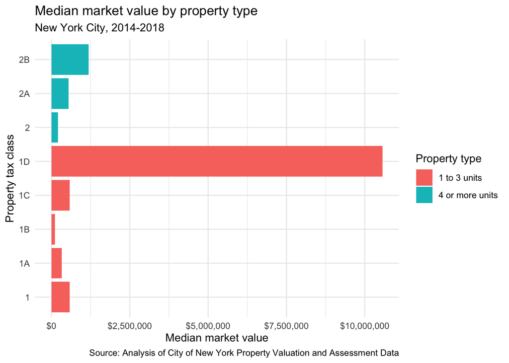

```r
res_data |>
  group_by(TAXCLASS) |>
  summarize(medvalcat = median(FULLVAL)) |>
    mutate(bld_type = case_when(
    TAXCLASS %in% c("1", "1A", "1B", "1C", "1D") ~ "1 to 3 units",
    TAXCLASS %in% c(2, "2A", "2B") ~ "4 or more units",
    TRUE ~ NA)) |>
  filter(!is.na(bld_type)) |>
  ggplot() +
  geom_col(mapping = aes(y = TAXCLASS, x = medvalcat, fill = bld_type)) +
  labs(
    title = "Median market value by property type",
    subtitle = "New York City, 2014-2018",
    fill = "Property type",
    caption = "Source: Analysis of City of New York Property Valuation and Assessment Data"
    ) +
  xlab("Median market value") +
  ylab("Property tax class") +
  scale_x_continuous(labels = label_dollar()) +
  theme_minimal()
```

This breakdown clearly shows that the outlier is class 1D - the median property value is far above any other category. New York City defines 1D as “Large, Cooperative Properties Composed of Individually Owned Homes Upon Cooperatively Owned Land; Select Bungalow Colonies (e.g. Breezy Point)”. It seems like these might be very large properties containing multiple standalone/semi-detached homes, yet still appearing in the data as a single property since they are owned by a cooperative. If this is the case, I’m not sure why NYC puts them in the “1-3 units” category.

I also wonder if 1D is just a very small category, being influenced by a few outlier data points?

```r
res_data |>
  filter(yearcln == 2018) |>
  group_by(TAXCLASS) |>
  summarize(n())
```

```
# A tibble: 9 × 2
  TAXCLASS  `n()`
  <chr>     <int>
1 1        657113
2 1A        22456
3 1B          138
4 1C         1518
5 1D           29
6 2        202900
7 2A        40426
8 2B        14342
9 2C        15289
```

Indeed, there are only 29 “1D” properties in the data for 2018 (I filtered by year so as to not count properties as duplicates; properties are typically assessed every year.)

This finding has less direct implications on policy, but more on policy analysis: if I were making real decisions for NYC, I would be sure to fully investigate why these properties are categorized the way they are, and whether adjustments are needed to ensure they are being reflected properly in my analyses.

## Third visualization: How has the housing type mix changed over time?

Since we’re just looking at a 5-year timespan, I don’t expect to see large changes in the mix of housing types across different years. Still, any changes we do see might point to either a) trends in new housing construction, or b) changes in the way properties are classified for tax purposes. Both of these could be important to informing ongoing tax policy and zoning ordinances that restrict what types of housing can be built on certain plots.

Here, I am using the slightly more detailed “Building Class” field (vs. “Tax Class” used above) to distinguish between types of dwellings. A dictionary of the Building Class types can be found [here](https://www.nyc.gov/assets/finance/jump/hlpbldgcode.html).

First, I need to do some additional data manipulation: I create a table with the total number of properties listed that year.

```r
yearsums <- res_data |>
  filter(!is.na(bldg_cat)) |>
  group_by(yearcln) |>
  summarize(yeartot = n())
```

I will link this to my data to build the visualization:

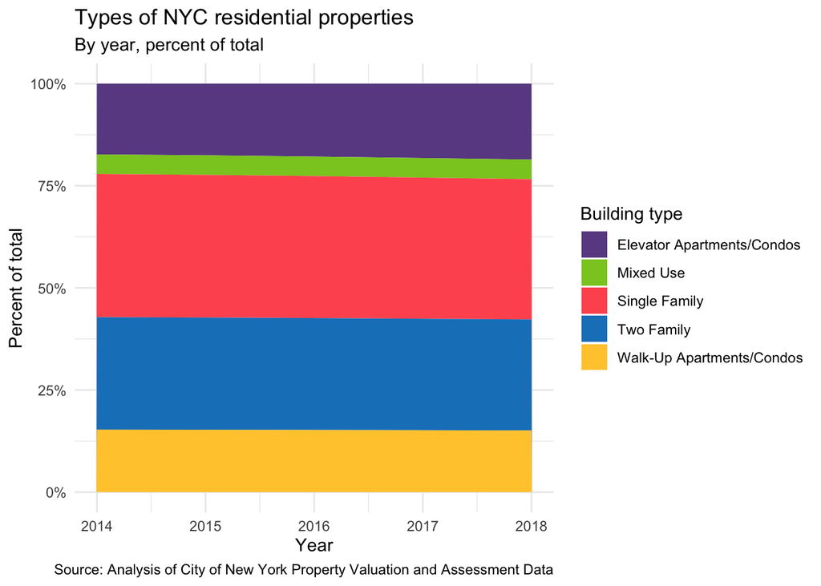

```r
res_data |>
  left_join(yearsums, by = join_by(yearcln)) |>
  group_by(bldg_cat, yearcln) |>
  summarize(count_bldg = n(), yeartot2 = mean(yeartot)) |>
  filter(!is.na(bldg_cat)) |>
  mutate(pct_tot = count_bldg / yeartot2)  |>
  ggplot() +
  geom_area(
    aes(
      x = yearcln,
      y = pct_tot,
      fill = bldg_cat,
        )
    ) +
  scale_fill_manual(
        values = c("#6a4c93","#8ac926","#ff595e","#1982c4","#ffca3a")
  ) +
  scale_y_continuous(
    labels = label_percent()
    ) +
  labs(
    title = "Types of NYC residential properties",
    subtitle = "By year, percent of total",
    fill = "Building type",
    caption = "Source: Analysis of City of New York Property Valuation and Assessment Data"
  ) +
  xlab("Year") +
  ylab("Percent of total") +
  theme_minimal()
```

My main takeaway here is that the housing mix did not changed very much from 2014-2018! Elevator apartments and condos seem to be slightly more prevalent than before; otherwise, this view does not show much change. We could consider a different type of visualization if we wanted to take a closer look at changes in each category. However, this visualization tells us a few important things:

1. There likely haven’t been any big, sweeping changes to how properties are categorized; otherwise we’d see much more year-over year change.
2. New housing may be concentrated in one category or another, but it’s not making a big enough impact in any one category to change the overall mix.
3. There is a lot more single- and two-family housing in NYC than I might have expected. However: it’s important to note that this is a count of properties, not units; the multi-unit buildings in the “Elevator” and “Walk-Up” categories typically house many more people. Still, there are definitely land-use implications here; single-family housing takes up much more space per unit.

## Fourth visualization: How are housing types spread across the city?

I want to map the properties to get a sense of distribution across the city, with more detail than just looking borough-by-borough. Unfortunately, only a subset of my data has longitude and latitude. I am creating a new dataframe with the properties for which geospatial data are available, so as not to place all four visualizations under this constraint.

```r
res_spatial <- res_data |>
  filter(!is.na(Longitude)) |>
  filter(!is.na(Latitude)) |>
  filter(yearcln == 2018) |>
  st_as_sf(coords = c("Longitude", "Latitude")) |>
  st_set_crs(value = 4326)

nyc_counties <- counties(cb = TRUE, progress_bar = FALSE, year = 2018) |>
  filter(STATEFP == "36",
         COUNTYFP %in% c("005","047","061","081","085")
  )
```

Now making the map: Each dot represents a property, with different property types represented by the dot colors. Note that my subsample is also restricted to 2018 - otherwise, we’d see overlapping points for buildings that appear in multiple years of data.

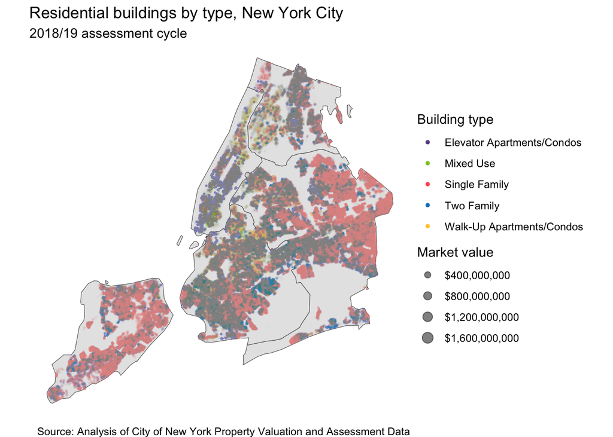

```r
res_spatial |>
  filter(!is.na(bldg_cat)) |>
  ggplot() +
  geom_sf(data = nyc_counties) +
  geom_sf(aes(color = bldg_cat, size = FULLVAL), alpha = 0.01) +
  scale_color_manual(
        values = c("#6a4c93","#8ac926","#ff595e","#1982c4","#ffca3a")
  ) +
  scale_size_continuous(
    range = c(0.25, 4),
    labels = label_dollar()
    ) +
  labs(
    title = "Residential buildings by type, New York City",
    subtitle = "2018/19 assessment cycle",
    color = "Building type",
    size = "Market value",
    caption = "Source: Analysis of City of New York Property Valuation and Assessment Data"
  ) +
  guides(
    color = guide_legend(override.aes = list(alpha = 1, size = 1)),
    size = guide_legend(override.aes = list(alpha = 0.5))
    ) +
  theme_void()
```

The map shows us that single-family housing (pink/red) is very much concentrated in Staten Island and eastern Queens. Manhattan is dominated by elevator apartments/condos (purple), with some clusters of walk-ups (yellow) at the south and north ends of the island. Brooklyn, The Bronx, and western Queens are very heterogeneous, with all types of housing visible.

I also note that Manhattan looks relatively sparse - while it does have a larger concentration of commercial buildings (and therefore probably less housing) than the other boroughs, there may also be other housing types I chose to exclude which are represented there. I chose to exclude some codes that I could not easily interpret and group into meaningful categories: for instance, “RR” properties are “Condominium Rentals”, which tells me nothing about the size or number of units.

The concentration of single-family housing in outer boroughs is a good starting point for policy conversations about affordability. A next step would be to overlay these findings with zoning restrictions: Do these areas have single-family homes because zoning only allows for that type of residence? If so, we could consider rezoning to increase housing density and ease pressure on existing housing stock. However, doing so would require becoming familiar with these areas, neighborhood characteristics, and resident needs, to make sure that we serve the existing community as well as the city at large.